# Variety Trial Analysis Report

AJ Brown

# 1. Overview and analysis workflow

This report is a front end for the variety‑trial backend in `r_equivalent.R`. It runs the analysis, then summarizes key outputs and the modeling decisions that were taken.

The backend currently follows these rules:

- **Stage 1, within each environment**
  - Try spatial `nlme::lme` models with candidate covariance structures (`expa`, `exp`, `sph`, `gau`) and choose the best by AICc when at least one converges.
  - If all spatial fits fail, fall back to:
    - **RCBD** via `lme4::lmer(yield ~ entry + (1 | rep))` when there are at least two reps.
    - **Fixed‑effects ANOVA** via `lm(yield ~ entry)` when replication is inadequate or `lmer` fails.
- **Stage 2B, across‑environment LS‑means**
  - If there are **two or more environments with LS‑means**, fit an inverse‑variance weighted meta‑analysis with a random environment effect and compute Tukey‑adjusted CLD letters.
  - If there is **only one environment**, skip meta‑analysis and compute LS‑means and Tukey CLD directly within that environment.
- **Stage 2A, BLUPs**
  - When multiple environments exist, fit a MET mixed model with random `env`, `env:rep`, `entry`, and `entry:env`.
  - With a single environment, fit a reduced model with random `entry` and, when possible, random `rep`.
  - If mixed models fail, fall back to `lm(yield ~ entry)` and report entry means with standard errors.

The sections below show how these rules were applied for this particular dataset, together with environment summaries, LS‑means, CLD letters, BLUPs, and diagnostic plots.

# 2. Run backend and capture results

## 2.1 Analysis configuration and decision summary

Key analysis configuration and decision rules for this run

| Item | Value |
| --- | --- |
| Input CSV | ../real_data/MilletVT2025.csv |
| Output directory | ../real_output |
| Alpha level | 0.05 |
| Number of environments in trial | 1 |
| Number of environments with LS-means (Stage 1) | 1 |
| Stage 2B mode | Single-environment analysis (env = MilletVT_2025); meta-analysis skipped, LS-means + Tukey CLD computed within that environment |
| Stage 2A BLUP mode | Single environment, multiple reps: random entry and random rep; may fall back to lm(yield ~ entry) |

Interpretation:

- The **Stage 2B mode** tells you whether a proper across‑environment meta‑analysis was fit or whether the code reverted to a single‑environment LS‑means analysis.
- The **BLUP mode** clarifies how many random effects were included in the MET model, given the number of environments and reps present in the data.

# 3. Data characteristics

This section summarizes the trial data used by the backend. Yields with `NA` are excluded from model fitting, but they are counted here for context.

Environment-level summary of plots and replication

| env | n_plots | n_missing | n_used | n_rep | n_entry |
| --- | --- | --- | --- | --- | --- |
| MilletVT_2025 | 160 | 16 | 144 | 8 | 20 |

For a quick visual check or to debug unusual environments, you may wish to view the first few rows of the raw trial file.

First 10 rows of the input trial data

| site | year | env | rep | row | col | entry | yield |
| --- | --- | --- | --- | --- | --- | --- | --- |
| MilletVT | 2025 | MilletVT_2025 | 2 | 5 | 1 | 1 | NA |
| MilletVT | 2025 | MilletVT_2025 | 3 | 10 | 1 | 2 | NA |
| MilletVT | 2025 | MilletVT_2025 | 2 | 7 | 1 | 3 | NA |
| MilletVT | 2025 | MilletVT_2025 | 4 | 13 | 1 | 7 | NA |
| MilletVT | 2025 | MilletVT_2025 | 3 | 9 | 1 | 8 | NA |
| MilletVT | 2025 | MilletVT_2025 | 4 | 16 | 1 | 9 | NA |
| MilletVT | 2025 | MilletVT_2025 | 4 | 15 | 1 | 10 | NA |
| MilletVT | 2025 | MilletVT_2025 | 1 | 3 | 1 | 11 | NA |
| MilletVT | 2025 | MilletVT_2025 | 3 | 12 | 1 | 12 | NA |
| MilletVT | 2025 | MilletVT_2025 | 4 | 14 | 1 | 13 | NA |

# 4. Stage 1: within-environment models

Stage 1 selects a covariance structure for each environment or falls back to simpler models when spatial fits fail. The table below shows the chosen model and (when available) its AICc.

Stage 1: model specification by environment (fixed, random, engine, and selected residual/covariance structure)

| env | engine | method | fixed | random | cov_selected |
| --- | --- | --- | --- | --- | --- |
| MilletVT_2025 | nlme::lme | REML | yield ~ entry | ~ 1 &#124; rep | sph |

The next table aggregates how often each covariance / fallback type was used.

Frequency of Stage 1 covariance and fallback choices

| Covariance / fallback | Number of environments |
| --- | --- |
| sph | 1 |

Stage 1: full model-selection table (all covariance candidates and fallbacks, with AIC/AICc/BIC and best flag)

| env | cov | converged | logLik | k | AIC | AICc | BIC | delta_AICc | best |
| --- | --- | --- | --- | --- | --- | --- | --- | --- | --- |
| MilletVT_2025 | sph | TRUE | -896.2436 | 24 | 1840.487 | 1850.571 | 1908.174 | 0.0000000 | TRUE |
| MilletVT_2025 | gau | TRUE | -896.3515 | 24 | 1840.703 | 1850.787 | 1908.390 | 0.2157971 | FALSE |
| MilletVT_2025 | expa | TRUE | -896.9010 | 24 | 1841.802 | 1851.886 | 1909.489 | 1.3147483 | FALSE |
| MilletVT_2025 | exp | TRUE | -896.9010 | 24 | 1841.802 | 1851.886 | 1909.489 | 1.3147483 | FALSE |

Interpretation:

- Spatial models (`expa`, `exp`, `sph`, `gau`) indicate successful fitting of a spatial `nlme` model.
- `none_rcbd` indicates that all spatial fits failed and a randomized complete block design model (`lmer`) was used.
- `none_lm` indicates a further fallback to fixed‑effects ANOVA (`lm`) when replication or convergence was insufficient for random block effects.

# 5. Stage 2B: across-environment LS-means and CLD

If more than one environment contributed LS‑means, Stage 2 performs an inverse‑variance meta‑analysis with a random environment effect and uses Tukey‑adjusted groupings to summarize differences among entries. When only one environment is available, these LS‑means and CLD letters are computed within that environment instead.

| entry | estimate | stderr | df | lower.CL | upper.CL | LSD_0.05 | LSD_0.30 | group |
| --- | --- | --- | --- | --- | --- | --- | --- | --- |
| 18 | 5001.135 | 116.6894 | 109.3725 | 4769.869 | 5232.401 | 306.9713 | 161.3673 | NA |
| 10 | 4968.507 | 116.6894 | 109.3725 | 4737.241 | 5199.773 | 306.9713 | 161.3673 | NA |
| 4 | 4906.206 | 109.5496 | 104.2687 | 4688.971 | 5123.440 | 306.9713 | 161.3673 | NA |
| 19 | 4904.937 | 116.6894 | 109.3725 | 4673.671 | 5136.203 | 306.9713 | 161.3673 | NA |
| 1 | 4898.150 | 116.6894 | 109.3725 | 4666.885 | 5129.416 | 306.9713 | 161.3673 | NA |
| 15 | 4854.691 | 116.6894 | 109.3725 | 4623.425 | 5085.957 | 306.9713 | 161.3673 | NA |
| 3 | 4827.342 | 116.6894 | 109.3725 | 4596.077 | 5058.608 | 306.9713 | 161.3673 | NA |
| 5 | 4691.591 | 109.5496 | 104.2687 | 4474.357 | 4908.826 | 306.9713 | 161.3673 | NA |
| 7 | 4576.300 | 116.6894 | 109.3725 | 4345.034 | 4807.566 | 306.9713 | 161.3673 | NA |
| 16 | 4552.117 | 116.6894 | 109.3725 | 4320.851 | 4783.383 | 306.9713 | 161.3673 | NA |
| 2 | 4458.060 | 116.6894 | 109.3725 | 4226.794 | 4689.326 | 306.9713 | 161.3673 | NA |
| 6 | 4367.051 | 109.5496 | 104.2687 | 4149.817 | 4584.286 | 306.9713 | 161.3673 | NA |
| 8 | 4353.265 | 116.6894 | 109.3725 | 4121.999 | 4584.531 | 306.9713 | 161.3673 | NA |
| 11 | 4279.854 | 116.6894 | 109.3725 | 4048.588 | 4511.120 | 306.9713 | 161.3673 | NA |
| 17 | 4260.005 | 116.6894 | 109.3725 | 4028.739 | 4491.271 | 306.9713 | 161.3673 | NA |
| 20 | 4251.850 | 109.5496 | 104.2687 | 4034.616 | 4469.085 | 306.9713 | 161.3673 | NA |
| 12 | 4238.838 | 116.6894 | 109.3725 | 4007.572 | 4470.104 | 306.9713 | 161.3673 | NA |
| 9 | 4085.274 | 116.6894 | 109.3725 | 3854.008 | 4316.540 | 306.9713 | 161.3673 | NA |
| 14 | 3972.914 | 116.6894 | 109.3725 | 3741.649 | 4204.180 | 306.9713 | 161.3673 | NA |
| 13 | 3850.628 | 116.6894 | 109.3725 | 3619.362 | 4081.894 | 306.9713 | 161.3673 | NA |

*LSD_0.05 and LSD_0.30 are single, model-based least significant difference thresholds derived from the average standard error of pairwise entry contrasts (unadjusted), using the across-environment model. Differences in adjusted mean yield larger than these thresholds are detectable at the corresponding nominal α level, under the usual equal-precision approximation.*

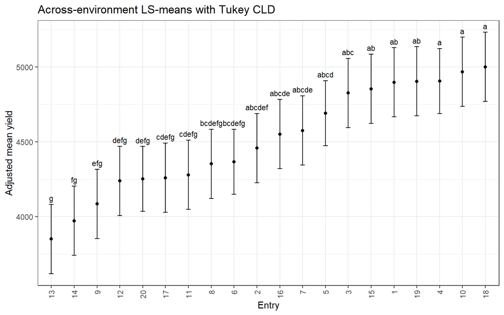

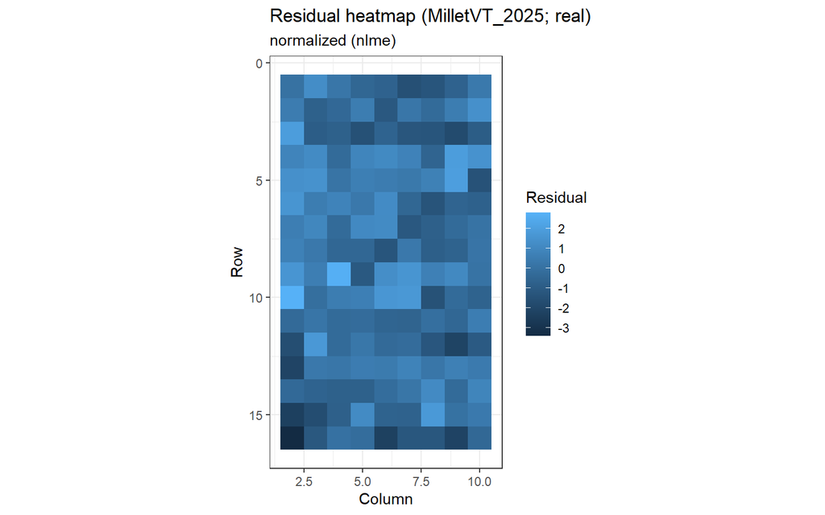

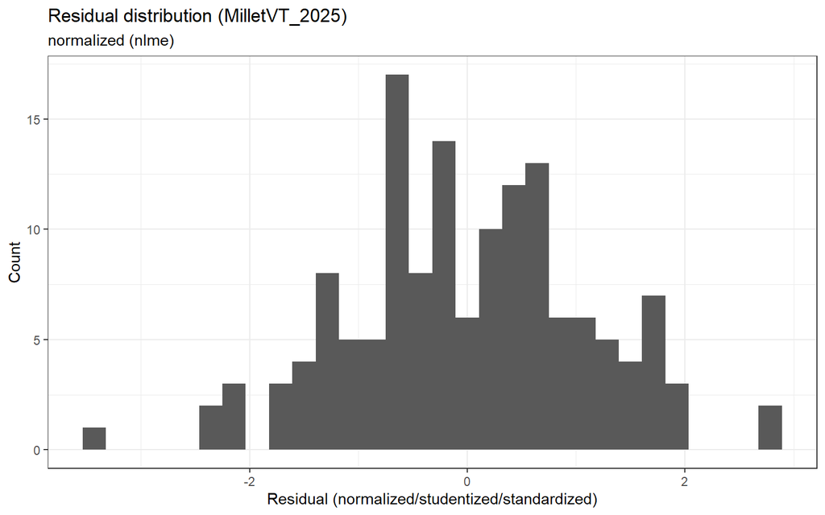

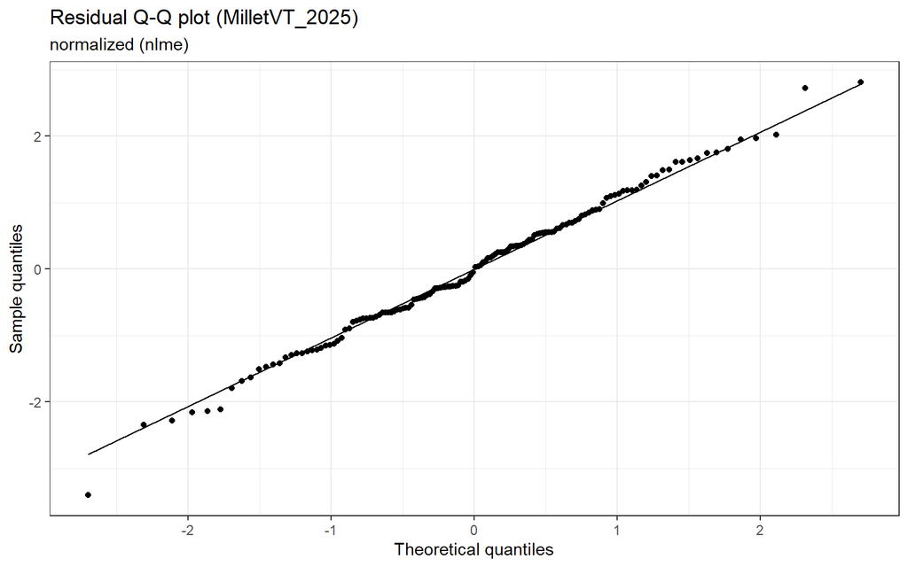

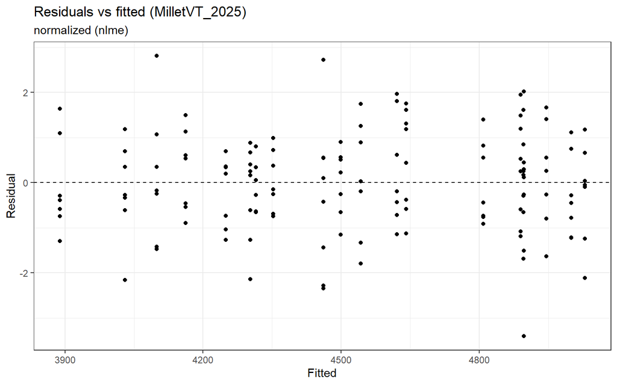

Interpretation:

- Entries that share at least one letter in the CLD column are **not** significantly different at the chosen alpha (Tukey adjustment).
- Entries with no shared letters are significantly different in yield.
- You can combine this with a practical threshold (for example, a minimum yield difference) to identify entries that are both statistically and agronomically distinct.

# 6. Stage 2A: BLUPs for entry performance

Entry BLUPs (Best Linear Unbiased Predictions) are model-based predictions of each entry’s underlying performance when entries are treated as random effects in a mixed model. BLUPs borrow strength across environments and replications, incorporate the estimated variance components (including G×E), and shrink predictions toward the grand mean when data for an entry are limited. This produces more stable and reliable rankings than simple means or per-environment LS-means, particularly when the design is unbalanced or entries are missing in some environments. BLUPs therefore represent the best available predictor of an entry’s expected performance in future environments.

Entry BLUPs and associated standard errors

| entry | BLUP | SE |
| --- | --- | --- |
| 1 | 345.03081 | 109.3897 |
| 2 | -51.42109 | 109.3897 |
| 3 | 281.82960 | 109.3897 |
| 4 | 357.23885 | 103.3151 |
| 5 | 161.25172 | 103.3151 |
| 6 | -135.12022 | 103.3151 |
| 7 | 55.70646 | 109.3897 |
| 8 | -145.94820 | 109.3897 |
| 9 | -387.20948 | 109.3897 |
| 10 | 409.48585 | 109.3897 |
| 11 | -212.01664 | 109.3897 |
| 12 | -249.16385 | 109.3897 |
| 13 | -598.86568 | 109.3897 |
| 14 | -488.88308 | 109.3897 |
| 15 | 305.82951 | 109.3897 |
| 16 | 33.57020 | 109.3897 |
| 17 | -230.59015 | 109.3897 |
| 18 | 437.92548 | 109.3897 |
| 19 | 351.67221 | 109.3897 |
| 20 | -240.32230 | 103.3151 |

Interpretation:

- Larger BLUPs correspond to higher predicted performance on the chosen yield scale (relative to the grand mean).
- Standard errors quantify the uncertainty in each BLUP; wide differences in SE often reflect uneven replication or missingness across environments.

## CV Summary

Stage 1 CV by environment (computed from Stage 1 residual RMSE and mean yield)

| env | n_used | mean_y | rmse | cv_pct | cov_selected |
| --- | --- | --- | --- | --- | --- |
| MilletVT_2025 | 144 | 4512.21 | 291.1994 | 6.453588 | sph |

# 7. Field layout heatmap and summary plots

The function `make_summary_plots()` from the backend produces a field layout heatmap for one example environment and reuses the CLD plot logic.

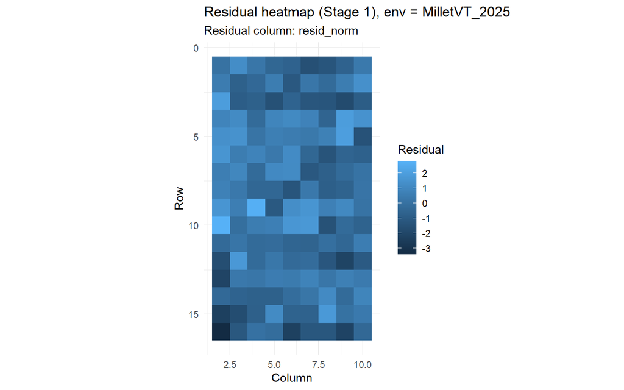

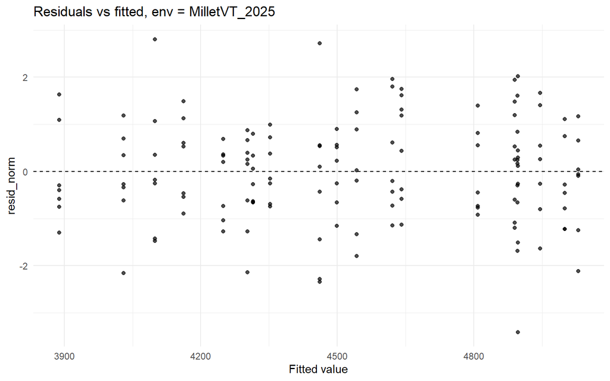

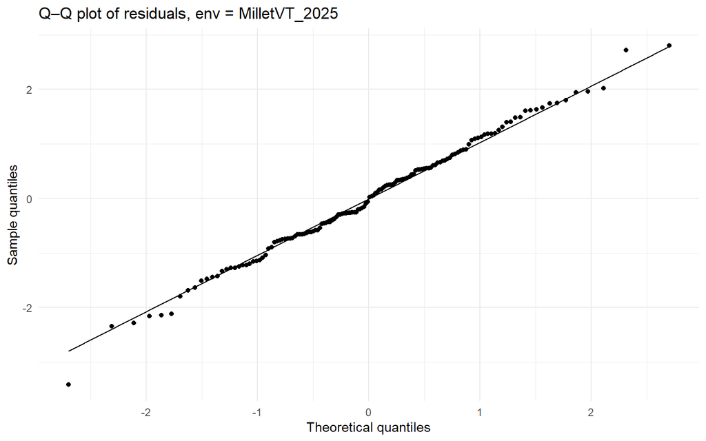

Potential outliers flagged by backend (env = MilletVT_2025)

| env | rep | row | col | entry | yield | fitted | resid | flag_outlier |
| --- | --- | --- | --- | --- | --- | --- | --- | --- |
| MilletVT_2025 | 4 | 16 | 2 | 3 | 3856.91 | 4897.046 | -3.406382 | TRUE |

The heatmap is helpful for visually checking residual spatial patterns in the residuals from the selected Stage-1 model (for example, bands, patches, or gradients) that might motivate alternative spatial structures or additional covariates.

# 8. Backend run report

If the backend wrote a `run_report.txt` file, it is reproduced below verbatim for full transparency.

````
## ```text
## Variety Trial Analysis run report
## --------------------------------
## Timestamp: 2025-12-18 13:22:08 MST
## Input file: C:\Users\ansle\OneDrive\Documents\GitHub\sally-jd-yield-analysis\real_data\MilletVT2025.csv
## Output directory: C:\Users\ansle\OneDrive\Documents\GitHub\sally-jd-yield-analysis\real_output
## Data type guess: real_or_external
## Alpha level: 0.05
##
## Data summary:
##   Total rows: 160
##   Total missing yields: 16
##   Rows used in modeling (non-missing yield): 144
##   Number of environments with LS-means: 1
##
## Environment-level summary:
##   Env MilletVT_2025: 160 plots (144 used, 16 missing); reps = 8, entries = 20
##
## Stage 1 (per-environment models):
##   Spatial covariance candidates: expa, exp, sph, gau
##   Explicit model specs written to: model_specs_stage1.csv
##   Full model-selection table written to: stage1_model_selection.csv
##   Plot-level diagnostics written to: diagnostics_stage1.csv
##   CV summary written to: cv_by_env.csv
##   Environments using spatial covariance (expa/exp/sph/gau): 1
##   Environments using RCBD fallback (none_rcbd): 0
##   Environments using fixed-effects ANOVA fallback (none_lm): 0
##   Best covariance per environment:
##     Env MilletVT_2025: best_cov = sph, best_AICc = 1850.57
##
## Stage 2B (across-environment LS-means):
##   Mode: single_env_within_trial (env = MilletVT_2025)
##   Description: only one environment present; meta-analysis skipped. Within-environment LS-means and Tukey CLD computed directly from raw data for that environment.
##
## Stage 2A (BLUPs):
##   Mode: single_env_multi_rep (random entry and random rep; may fall back to lm)
##   Description: entry treated as random; env and env:rep random effects included when multiple environments and reps are available.
##
## Key modeling assumptions and rules:
##   • Rows with NA yield are excluded from all model fitting.
##   • Entry is always treated as a factor.
##   • Stage 1 prefers spatial nlme models; if all spatial fits fail for an environment, the model falls back to RCBD (lmer) or, if that fails or reps are insufficient, to fixed-effects ANOVA (lm).
##   • Stage 2 meta-analysis is only meaningful when ≥ 2 environments are present; with a single environment, across-env meta is skipped and within-env LS-means + Tukey CLD are used instead.
##   • BLUPs treat entry as random and, when possible, include env and env:rep random effects; if mixed models fail to converge, the code falls back to lm(yield ~ entry) and uses emmeans to summarize entry effects.
##   • Confidence intervals and p-values follow standard approximations from nlme/lme4/emmeans and may be unstable when degrees of freedom are small or designs are highly unbalanced.
## ```
````

# 9. Description of Outputs

The backend generates a standardized set of analysis files in the specified output directory. These files document the fitted models, adjusted means, significance groupings, and random-effect predictions used throughout this report.

### 1. `lsm_stage1.csv`

This file contains the **per-environment least-squares means** and their standard errors after the Stage-1 spatial analysis. Each row corresponds to a specific combination of environment and entry. Columns include:

- `env`: environment identifier
- `entry`: entry identifier
- `estimate`: environment-specific adjusted mean
- `stderr`: standard error of the estimate
- `cov`: selected spatial covariance model for that environment
- additional columns describing the covariance fit, if applicable

This file reflects only within-environment information and is used as the foundation for Stage-2 summarization.

### 2. `lsm_across.csv`

This file contains the **across-environment adjusted means** for each entry. The estimates are obtained either from:

- an inverse-variance meta-analytic model across environments, when multiple environments exist, or
- a within-environment model if only one environment is present.

Columns include:

- `entry`: entry identifier
- `estimate`: overall adjusted mean across environments
- `lower.CL`, `upper.CL`: confidence limits, when computable
- additional model-based summaries depending on the data structure

These are the primary estimates used for ranking and graphical display in the report.

### 3. `diffs_across.csv`

This file contains **pairwise comparisons** among entries based on Tukey adjustment. Columns include:

- `contrast`: entry pair (A minus B)
- `estimate`: estimated difference
- `SE`: standard error of the difference
- `df`: degrees of freedom (if available)
- `t.ratio`, `p.value`: test statistics and adjusted significance

This file is useful for examining which entries differ significantly and for inspecting comparisons that do not appear in the compact letter display.

### 4. `cld_across.csv`

This file holds the **compact letter display**, a concise encoding of the Tukey groupings. Each entry receives a string of letters. Entries sharing at least one letter are not significantly different at the chosen alpha level.

Columns:

- `entry`: entry identifier
- `group`: the assigned grouping letters

These letters are used directly in the Tukey summary figure.

### 5. `entry_blups.csv`

This file contains **BLUPs**, the Best Linear Unbiased Predictions of entry performance under the mixed-effects MET model. BLUPs incorporate random environment, random replication effects, and entry-by-environment interaction when present.

Columns include:

- `entry`: entry identifier
- `BLUP`: predicted random effect for the entry
- `SE`: standard error of the prediction

BLUPs provide a stabilized estimate of underlying performance, especially when data are unbalanced or sparse.

### 6. `run_report.txt`

This plain-text file documents the modeling decisions made during execution. It includes:

- the input file used
- the number of environments and the number of usable plots
- which covariance structures were selected in Stage-1
- fallback behavior (for example, RCBD or fixed-effects replacements)
- the Stage-2 modeling mode (meta-analysis or within-environment)
- BLUP model structure and any singular-fit warnings
- assumptions and notes on missing data, replication, and confidence intervals

This file serves as an audit trail so that the user can verify exactly how the backend operated on the dataset.